# Estimating K600 from streammetabolizer for GBL

Kelly Loria

2025-01-31

## Background

This is a small, turbulent, shaded, streamed with a fair amount of fine particulate organic matter.

## Identifying reasonable modeled estimates of K600

We then ran the normal stream metabolizer model: `b_Kb_oipi_tr_plrckm.stan` to get modeled K600 to see if we could resolve the negative correlation between ER and K600. Priors on `K600_lnQ_nodes_meanlog` were set as 5 bins based on `rnorm(1000, mean = logQ_mean, sd = logQ_sd)` centered around the mean and logQ va;ues 1-2 sd away from the mean.

### Load GBL versions of metab data from different model segments with normal prior for gas exchange.

We chose segments of time where we believe GPP occurred and was greater than 0. These chunks of time are from a previous model where we binned flow and incorporated measured and estimated K600 priors from gas exchange measurements a the reach.

### Metabolism segements with CIs

Where GPP is in blue and ER is in orange.

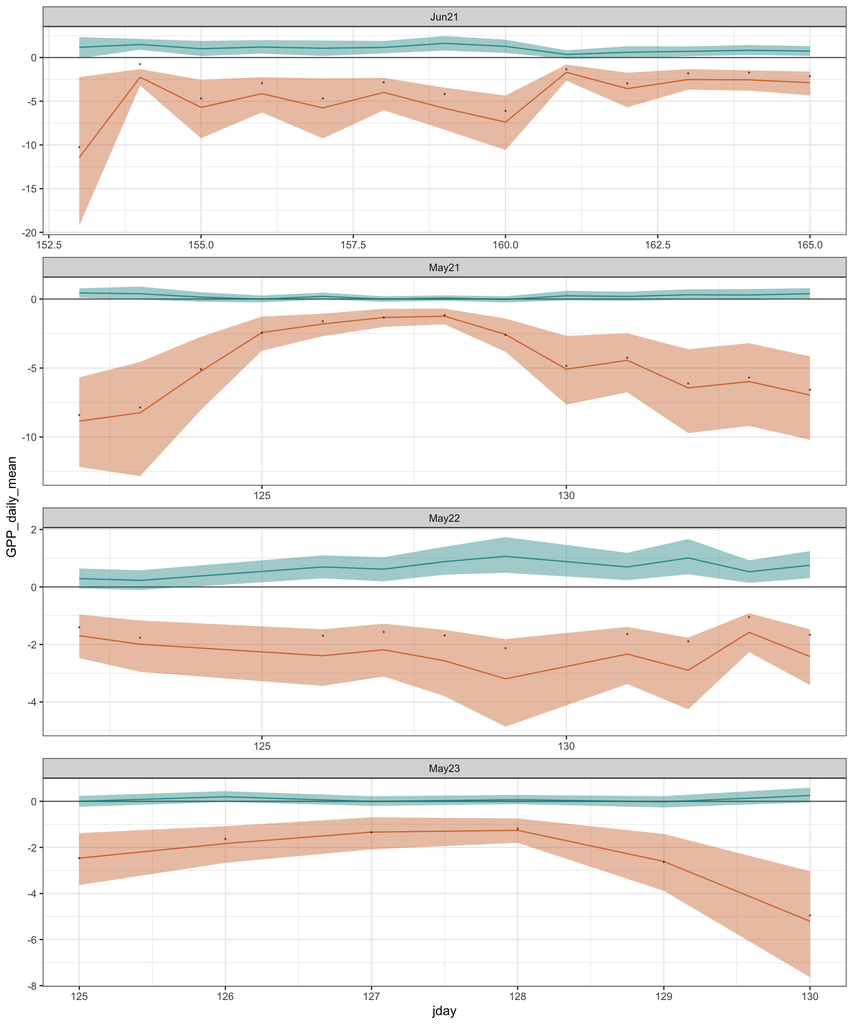

## Checking model convergence

** Not all all segments had great convergence.

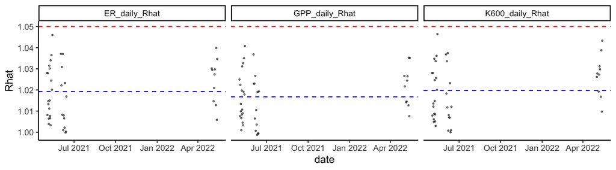

```
##       date                lab                 rmse               sd
##  Min.   :2021-05-01   Length:120         Min.   :0.02600   Min.   :0.08183
##  1st Qu.:2021-05-08   Class :character   1st Qu.:0.05183   1st Qu.:0.36078
##  Median :2021-05-23   Mode  :character   Median :0.09201   Median :0.43503
##  Mean   :2021-08-15                      Mean   :0.11585   Mean   :0.42122
##  3rd Qu.:2021-09-03                      3rd Qu.:0.13302   3rd Qu.:0.46960
##  Max.   :2022-05-15                      Max.   :0.43387   Max.   :0.75359
##                                          NA's   :16
##       min             max             range            nrmse
##  Min.   :6.022   Min.   : 7.802   Min.   :0.2227   Min.   :0.02340
##  1st Qu.:7.430   1st Qu.: 8.801   1st Qu.:1.2165   1st Qu.:0.03977
##  Median :7.738   Median : 9.033   Median :1.3600   Median :0.06643
##  Mean   :7.773   Mean   : 9.143   Mean   :1.3699   Mean   :0.07587
##  3rd Qu.:8.190   3rd Qu.: 9.479   3rd Qu.:1.5277   3rd Qu.:0.10308
##  Max.   :9.612   Max.   :10.815   Max.   :2.8733   Max.   :0.18608
##                                                    NA's   :16
##       minT             maxT           rangeT
##  Min.   : 1.790   Min.   : 5.53   Min.   :0.525
##  1st Qu.: 5.617   1st Qu.:11.55   1st Qu.:5.524
##  Median : 6.961   Median :12.90   Median :6.033
##  Mean   : 6.966   Mean   :12.72   Mean   :5.750
##  3rd Qu.: 8.165   3rd Qu.:14.25   3rd Qu.:6.559
##  Max.   :11.603   Max.   :17.25   Max.   :8.051
##
```

## Looking at the K600 and ER relationships

Here is the run configuration:

**bayes_specs_new**

`bayes_name_new <- mm_name(type = 'bayes', pool_K600 = "normal", err_obs_iid = TRUE, err_proc_iid = TRUE, ode_method = "trapezoid", deficit_src = 'DO_mod', engine = 'stan')`

Where each “lab” segment was run as individual model with the `K600_lnQ_nodes_meanlog` adjusted to match streamline in cms during that time.

### K-ER, K-Q, general K600 trends

```
## [1] -0.828
```

```
## [1] 0.013
```

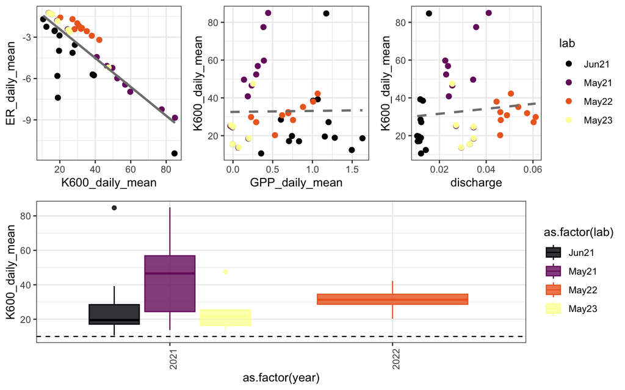

### Compared modeled and measured K600

Plots for (1) measured v modeled K600 and flow and (2) logK600 and log(flow+1).

Could be one poor measurement at the highest flow for measured gas exchange. But in general the modeled K600 does seem similar to the measured, which is kind of nice to see how robust the `pool_K600 = "normal"` is getting at K600.

```
## [1] 32.85907
```

```
## [1] 39.53105
```

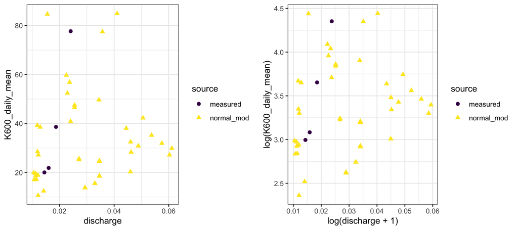